# Analyse des données

# Etude de la variable coût

##### …en fonction de la sinistralité

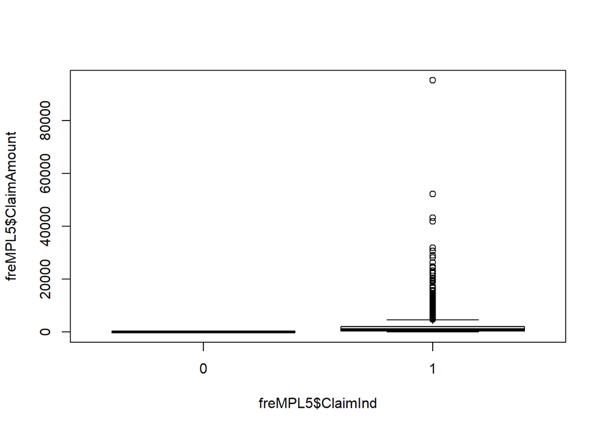

```r
plot(freMPL5$ClaimAmount ~ freMPL5$ClaimInd)
```

```r
summary(freMPL5$ClaimAmount[freMPL5$ClaimInd == 1]) #resumé lorsque de l'argent est demandé
```

```
##     Min.  1st Qu.   Median     Mean  3rd Qu.     Max.
##     8.84   345.71   800.95  2277.22  2089.58 95150.96
```

```r
summary(freMPL5$ClaimAmount[freMPL5$ClaimInd == 0]) #evidemment toujours nul
```

```
##    Min. 1st Qu.  Median    Mean 3rd Qu.    Max.
##       0       0       0       0       0       0
```

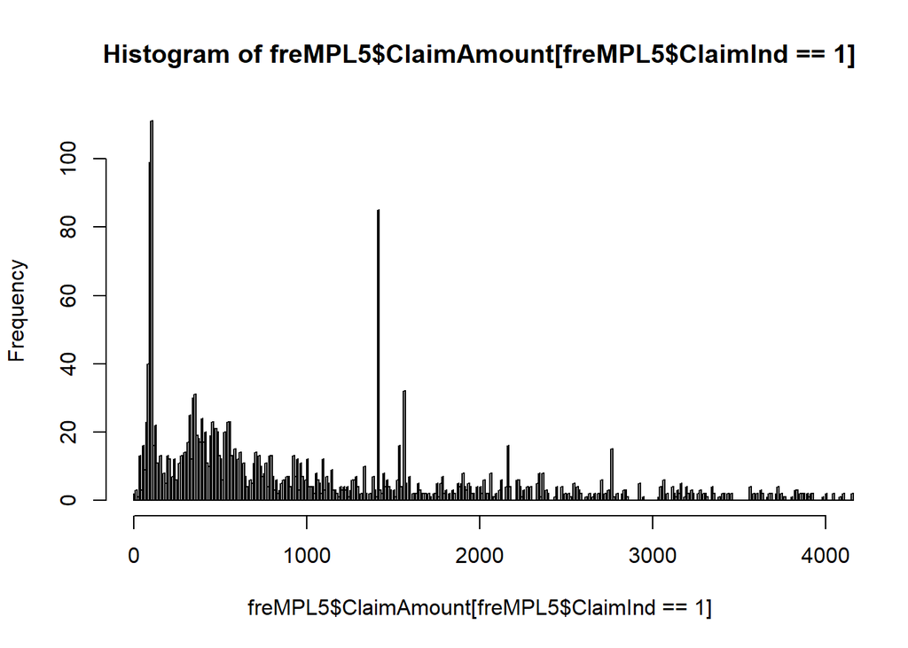

```r
hist(freMPL5$ClaimAmount[freMPL5$ClaimInd == 1], breaks=seq(0,100000,10),xlim=c(0,4000))
```

On a ici un graphique plus intéressant qui nous permettra de proposer éventuellement une loi pour la variable de coût. On remarque tout de fois quelques énormes pics de fréquence. Nous pouvons imaginer qu’il s’agit d’une dépense forfaitaire (comme par exemple un bris de glace qui a souvent le même prix).

On remarque un premier pic entre 90 et 110 et un autre 1410 et 1420. Regardons à quoi cela pourrait être dû :

```r
summary(freMPL5[freMPL5$ClaimAmount<110 & freMPL5$ClaimAmount>90,])
```

```
##     Exposure              LicAge     RecordBeg            RecordEnd
##  Min.   :0.0540   [0,50]     : 2   Min.   :2004-01-01   Min.   :2004-01-21
##  1st Qu.:0.4610   (50,100]   :12   1st Qu.:2004-01-01   1st Qu.:2004-07-01
##  Median :0.6565   (100,200]  :36   Median :2004-03-26   Median :2004-10-02
##  Mean   :0.6222   (200,300]  :47   Mean   :2004-04-03   Mean   :2004-09-04
##  3rd Qu.:0.8330   (300,400]  :46   3rd Qu.:2004-06-03   3rd Qu.:2004-11-15
##  Max.   :1.0000   (400,500]  :39   Max.   :2004-11-22   Max.   :2004-12-27
##                   (500,1e+03]:28                        NA's   :131
##     Gender     MariStat     SocioCateg                    VehUsage
##  Female: 67   Alone: 24   CSP50  :120   Private               : 53
##  Male  :143   Other:186   CSP60  : 31   Private+trip to office:112
##                           CSP55  : 28   Professional          : 39
##                           CSP1   :  6   Professional run      :  6
##                           CSP42  :  6
##                           CSP48  :  6
##                           (Other): 13
##     DrivAge      HasKmLimit  ClaimAmount      ClaimNbResp     ClaimNbNonResp
##  Min.   :22.00   0:199      Min.   : 90.02   Min.   :0.0000   Min.   :0.0000
##  1st Qu.:36.00   1: 11      1st Qu.: 97.32   1st Qu.:0.0000   1st Qu.:0.0000
##  Median :47.00              Median :102.59   Median :0.0000   Median :0.0000
##  Mean   :47.67              Mean   : 99.60   Mean   :0.2857   Mean   :0.3667
##  3rd Qu.:58.00              3rd Qu.:102.59   3rd Qu.:0.7500   3rd Qu.:1.0000
##  Max.   :81.00              Max.   :109.51   Max.   :3.0000   Max.   :2.0000
##
##  ClaimNbParking   ClaimNbFireTheft  ClaimNbWindscreen    OutUseNb
##  Min.   :0.0000   Min.   :0.00000   Min.   :0.0000    Min.   :0.0000
##  1st Qu.:0.0000   1st Qu.:0.00000   1st Qu.:0.0000    1st Qu.:0.0000
##  Median :0.0000   Median :0.00000   Median :0.0000    Median :0.0000
##  Mean   :0.0619   Mean   :0.02381   Mean   :0.5667    Mean   :0.3429
##  3rd Qu.:0.0000   3rd Qu.:0.00000   3rd Qu.:1.0000    3rd Qu.:0.0000
##  Max.   :1.0000   Max.   :1.00000   Max.   :3.0000    Max.   :5.0000
##
##     RiskArea    BonusMalus    ClaimInd     ObtLic     DrivAge_fact
##  7      :53   Min.   : 50.0   0:  0    [16,18]:65   (50,58] :40
##  10     :36   1st Qu.: 50.0   1:210    (18,19]:51   (45,50] :31
##  9      :32   Median : 50.0            (19,20]:24   (58,65] :26
##  6      :25   Mean   : 58.9            (20,21]:15   (30,35] :25
##  11     :22   3rd Qu.: 67.0            (21,25]:28   (35,40] :25
##  5      :16   Max.   :100.0            (25,63]:27   (65,120]:22
##  (Other):26                                         (Other) :41
```

```r
quantile(freMPL5$ClaimNbWindscreen[freMPL5$ClaimAmount<110 & freMPL5$ClaimAmount>90], seq(0,1,0.1))
```

```
##   0%  10%  20%  30%  40%  50%  60%  70%  80%  90% 100%
##    0    0    0    0    0    0    1    1    1    1    3
```

On remarque que cette tranche représente 8,7% des assurés qui ont eu recours à un remboursement et une grande partie (au moins 40%) de ces assurés ont eu au moins un bris de glace.

Pour le pic à 1410-1420 :

```r
summary(freMPL5[freMPL5$ClaimAmount<1419 & freMPL5$ClaimAmount>1409,])
```

```
##     Exposure              LicAge     RecordBeg            RecordEnd
##  Min.   :0.0750   [0,50]     : 0   Min.   :2004-01-01   Min.   :2004-03-01
##  1st Qu.:0.4440   (50,100]   : 2   1st Qu.:2004-01-01   1st Qu.:2004-07-01
##  Median :0.6420   (100,200]  : 5   Median :2004-01-09   Median :2004-09-01
##  Mean   :0.6252   (200,300]  :13   Mean   :2004-02-23   Mean   :2004-08-22
##  3rd Qu.:0.8940   (300,400]  :14   3rd Qu.:2004-04-09   3rd Qu.:2004-11-20
##  Max.   :1.0000   (400,500]  :34   Max.   :2004-10-01   Max.   :2004-12-22
##                   (500,1e+03]:17                        NA's   :31
##     Gender    MariStat    SocioCateg                   VehUsage
##  Female:23   Alone: 5   CSP50  :37   Private               :27
##  Male  :62   Other:80   CSP60  :15   Private+trip to office:40
##                         CSP55  :11   Professional          :13
##                         CSP46  : 7   Professional run      : 5
##                         CSP42  : 5
##                         CSP1   : 4
##                         (Other): 6
##     DrivAge      HasKmLimit  ClaimAmount    ClaimNbResp     ClaimNbNonResp
##  Min.   :22.00   0:80       Min.   :1409   Min.   :0.0000   Min.   :0.0000
##  1st Qu.:45.00   1: 5       1st Qu.:1419   1st Qu.:0.0000   1st Qu.:0.0000
##  Median :57.00              Median :1419   Median :0.0000   Median :0.0000
##  Mean   :54.32              Mean   :1418   Mean   :0.3294   Mean   :0.4353
##  3rd Qu.:64.00              3rd Qu.:1419   3rd Qu.:1.0000   3rd Qu.:1.0000
##  Max.   :81.00              Max.   :1419   Max.   :2.0000   Max.   :2.0000
##
##  ClaimNbParking   ClaimNbFireTheft ClaimNbWindscreen    OutUseNb
##  Min.   :0.0000   Min.   :0.0000   Min.   :0.0000    Min.   :0.0000
##  1st Qu.:0.0000   1st Qu.:0.0000   1st Qu.:0.0000    1st Qu.:0.0000
##  Median :0.0000   Median :0.0000   Median :0.0000    Median :0.0000
##  Mean   :0.1059   Mean   :0.1176   Mean   :0.3765    Mean   :0.2118
##  3rd Qu.:0.0000   3rd Qu.:0.0000   3rd Qu.:1.0000    3rd Qu.:0.0000
##  Max.   :1.0000   Max.   :1.0000   Max.   :3.0000    Max.   :2.0000
##
##     RiskArea    BonusMalus     ClaimInd     ObtLic     DrivAge_fact
##  7      :20   Min.   : 50.00   0: 0     [16,18]:26   (50,58] :22
##  9      :16   1st Qu.: 50.00   1:85     (18,19]:17   (65,120]:17
##  10     :15   Median : 50.00            (19,20]: 5   (58,65] :16
##  6      :13   Mean   : 54.33            (20,21]:11   (40,45] :10
##  11     :11   3rd Qu.: 52.00            (21,25]:13   (35,40] : 8
##  2      : 2   Max.   :107.00            (25,63]:13   (45,50] : 5
##  (Other): 8                                          (Other) : 7
```

```r
quantile(freMPL5$ClaimNbNonResp[freMPL5$ClaimAmount<1419 & freMPL5$ClaimAmount>1409], seq(0,1,0.1))
```

```
##   0%  10%  20%  30%  40%  50%  60%  70%  80%  90% 100%
##    0    0    0    0    0    0    0    1    1    1    2
```

```r
quantile(freMPL5$ClaimNbResp[freMPL5$ClaimAmount<1419 & freMPL5$ClaimAmount>1409], seq(0,1,0.1))
```

```
##   0%  10%  20%  30%  40%  50%  60%  70%  80%  90% 100%
##    0    0    0    0    0    0    0    0    1    1    2
```

# Etude de la variable d’indication de remboursement

```r
summary(freMPL5[freMPL5$ClaimInd == 0,])
```

```
##     Exposure              LicAge       RecordBeg            RecordEnd
##  Min.   :0.0010   [0,50]     : 318   Min.   :2004-01-01   Min.   :2004-01-02
##  1st Qu.:0.1660   (50,100]   : 979   1st Qu.:2004-01-01   1st Qu.:2004-04-26
##  Median :0.3470   (100,200]  :3406   Median :2004-04-28   Median :2004-07-07
##  Mean   :0.4024   (200,300]  :4121   Mean   :2004-05-12   Mean   :2004-07-16
##  3rd Qu.:0.6110   (300,400]  :4842   3rd Qu.:2004-09-01   3rd Qu.:2004-10-08
##  Max.   :1.0000   (400,500]  :5406   Max.   :2004-12-31   Max.   :2004-12-31
##                   (500,1e+03]:4232                        NA's   :11478
##     Gender       MariStat       SocioCateg                      VehUsage
##  Female: 7903   Alone: 3058   CSP50  :11008   Private               : 7818
##  Male  :15401   Other:20246   CSP60  : 5171   Private+trip to office:10915
##                               CSP55  : 2964   Professional          : 3735
##                               CSP1   :  833   Professional run      :  836
##                               CSP66  :  579
##                               CSP42  :  573
##                               (Other): 2176
##     DrivAge      HasKmLimit  ClaimAmount  ClaimNbResp     ClaimNbNonResp
##  Min.   :20.00   0:21505    Min.   :0    Min.   :0.0000   Min.   :0.0000
##  1st Qu.:39.00   1: 1799    1st Qu.:0    1st Qu.:0.0000   1st Qu.:0.0000
##  Median :51.00              Median :0    Median :0.0000   Median :0.0000
##  Mean   :50.66              Mean   :0    Mean   :0.2595   Mean   :0.3136
##  3rd Qu.:61.00              3rd Qu.:0    3rd Qu.:0.0000   3rd Qu.:1.0000
##  Max.   :95.00              Max.   :0    Max.   :4.0000   Max.   :6.0000
##
##  ClaimNbParking    ClaimNbFireTheft  ClaimNbWindscreen    OutUseNb
##  Min.   :0.00000   Min.   :0.00000   Min.   :0.0000    Min.   :0.0000
##  1st Qu.:0.00000   1st Qu.:0.00000   1st Qu.:0.0000    1st Qu.:0.0000
##  Median :0.00000   Median :0.00000   Median :0.0000    Median :0.0000
##  Mean   :0.08067   Mean   :0.07441   Mean   :0.4109    Mean   :0.2207
##  3rd Qu.:0.00000   3rd Qu.:0.00000   3rd Qu.:1.0000    3rd Qu.:0.0000
##  Max.   :4.00000   Max.   :3.00000   Max.   :8.0000    Max.   :5.0000
##
##     RiskArea      BonusMalus     ClaimInd      ObtLic       DrivAge_fact
##  7      :5531   Min.   : 50.00   0:23304   [16,18]:5437   (50,58] :5126
##  10     :4105   1st Qu.: 50.00   1:    0   (18,19]:5631   (65,120]:3916
##  6      :3493   Median : 50.00             (19,20]:2827   (58,65] :3063
##  9      :3432   Mean   : 57.55             (20,21]:1818   (45,50] :2527
##  11     :2649   3rd Qu.: 60.00             (21,25]:3982   (40,45] :2238
##  5      :1381   Max.   :185.00             (25,63]:3609   (30,35] :2203
##  (Other):2713                                             (Other) :4231
```

```r
summary(freMPL5[freMPL5$ClaimInd == 1,])
```

```
##     Exposure              LicAge      RecordBeg            RecordEnd
##  Min.   :0.0020   [0,50]     : 67   Min.   :2004-01-01   Min.   :2004-01-12
##  1st Qu.:0.4160   (50,100]   :123   1st Qu.:2004-01-01   1st Qu.:2004-07-01
##  Median :0.6110   (100,200]  :360   Median :2004-02-27   Median :2004-09-12
##  Mean   :0.6026   (200,300]  :479   Mean   :2004-03-21   Mean   :2004-08-26
##  3rd Qu.:0.8190   (300,400]  :493   3rd Qu.:2004-05-21   3rd Qu.:2004-11-01
##  Max.   :1.0000   (400,500]  :559   Max.   :2004-12-28   Max.   :2004-12-31
##                   (500,1e+03]:337                        NA's   :1197
##     Gender      MariStat      SocioCateg                     VehUsage
##  Female: 843   Alone: 348   CSP50  :1228   Private               : 672
##  Male  :1575   Other:2070   CSP60  : 430   Private+trip to office:1111
##                             CSP55  : 246   Professional          : 516
##                             CSP1   : 123   Professional run      : 119
##                             CSP46  :  83
##                             CSP66  :  80
##                             (Other): 228
##     DrivAge      HasKmLimit  ClaimAmount        ClaimNbResp
##  Min.   :20.00   0:2284     Min.   :    8.84   Min.   :0.0000
##  1st Qu.:38.00   1: 134     1st Qu.:  345.71   1st Qu.:0.0000
##  Median :49.00              Median :  800.95   Median :0.0000
##  Mean   :48.92              Mean   : 2277.22   Mean   :0.3259
##  3rd Qu.:59.00              3rd Qu.: 2089.58   3rd Qu.:1.0000
##  Max.   :88.00              Max.   :95150.96   Max.   :3.0000
##
##  ClaimNbNonResp   ClaimNbParking   ClaimNbFireTheft  ClaimNbWindscreen
##  Min.   :0.0000   Min.   :0.0000   Min.   :0.00000   Min.   :0.0000
##  1st Qu.:0.0000   1st Qu.:0.0000   1st Qu.:0.00000   1st Qu.:0.0000
##  Median :0.0000   Median :0.0000   Median :0.00000   Median :0.0000
##  Mean   :0.3929   Mean   :0.1046   Mean   :0.09553   Mean   :0.4764
##  3rd Qu.:1.0000   3rd Qu.:0.0000   3rd Qu.:0.00000   3rd Qu.:1.0000
##  Max.   :7.0000   Max.   :2.0000   Max.   :2.00000   Max.   :5.0000
##
##     OutUseNb         RiskArea     BonusMalus     ClaimInd     ObtLic
##  Min.   :0.0000   7      :503   Min.   : 50.00   0:   0   [16,18]:628
##  1st Qu.:0.0000   10     :461   1st Qu.: 50.00   1:2418   (18,19]:568
##  Median :0.0000   9      :356   Median : 50.00            (19,20]:279
##  Mean   :0.2605   11     :332   Mean   : 59.69            (20,21]:184
##  3rd Qu.:0.0000   6      :323   3rd Qu.: 65.00            (21,25]:391
##  Max.   :5.0000   5      :142   Max.   :156.00            (25,63]:368
##                   (Other):301
##    DrivAge_fact
##  (50,58] :485
##  (65,120]:331
##  (58,65] :317
##  (45,50] :285
##  (40,45] :271
##  (35,40] :233
##  (Other) :496
```

On remarque que LicAge et DrivAge réduisent le risque d’avoir un sinistre.

De même, plus le score de malus est haut et plus l’assuré a de risque d’avoir un sinistre.

Avoir une limite de kilomètres semblent aussi réduire les risques.

Nous avons déjà beaucoup analysé ces données dans les sections précédentes.

# Lien avec l’analyse proposée par Wultrish

Wultrish classe les données en plusieurs catégories. Nous allons donc classer les covariables telles que Wultrish le propose :

- covariables liées au conducteur : Gender, MariStat, SocioCateg, DrivAge
- covariables liées au véhicule : .
- covariables liées aux spécificités du contrat d’assurance : (exposure,) RecordBeg, RecordEnd, HasKmLimit
- covariables géographiques : RiskArea
- covariables liées à la conduite et l’expérience : licAge, VehUsage, BonusMalus, ClaimNbResp, ClaimNbNonResp, ClaimNbParking, ClaimNbFireTheft, ClaimNbWindscreen, OutUseNb

On remarque qu’on ne possède aucune caractéristique sur le type de véhicule que possède l’assuré. Cela pourra donc compliquer la tâche lors de l’estimation du coût moyen d’un sinistre pour un assuré. Cela devra être spécifié ou sera justifié lors de la sélection de modèle (notamment lors de la phase de prédiction).

Premièrement, on ne pourra pas avoir accès au genre lors de la tarification. Cela enlèvera donc une covariable.

Habituellement, on utilise une approche fréquence-sévérité où la fréquence est le nombre d’accidents que l’assuré a obtenu. Cependant, on aura ici que la fréquence est soit 1, soit 0 selon le fait qu’il ait eu un sinistre ou pas.

Nous aurons donc la formule suivante :

$$E[X_i]=E[F_i] \cdot E[B_i]$$

avec $B_i$ la variable de coût moyen et $F_i$ la variable de fréquence qui sera une $Ber(q_i)$ donc

$$E[F_i] = q_i$$

d’où

$$E[X_i]=q_i \cdot E[B_i]$$

Les variables ClaimNbResp, ClaimNbNonResp, ClaimNbParking, ClaimNbFireTheft, ClaimNbWindscreen, OutUseNb traitent des sinistres passés durant les 4 années précédentes. Ils permettront peut-être de déterminer si l’assuré a des risques d’avoir de nouveau ce genre de sinistres qui sont plus ou moins coûteux selon leur classification.

Pour la distribution des coûts moyens, on peut remarquer qu’il y a une “bosse” autour de 100€, ce qui pourrait être une concentration d’assurés ayant eu à déclencher la garantie bris de glace. Ne sachant par comment prédire cette donnée (nous n’avons pas une variable à expliquer pour cette garantie), nous pourrions essayer de faire une prédiciton à partir des données passées (ClaimWindscreen sur les 4 années précédentes). Mais alors, il faudra penser à une façon d’isoler cette garanti pour ne pas l’appliquer à tout le monde dans le modèle général.